# Homework 3 Answers

BSTA 513/613

Author

Nicky Wakim

Modified

May 15, 2026

## Questions Part 1

### Question 1

This question is taken from the Hosmer and Lemeshow textbook. The ICU study data set consists of a sample of 200 subjects who were part of a much larger study on survival of patients following admission to an adult intensive care unit (ICU). The dataset should be available in our shared folder. The major goal of this study was to develop a logistic regression model to predict the probability of survival to hospital discharge of these patients. In this question, the primary outcome variable is vital (survival) status at hospital discharge, STA. Clinicians associated with the study felt that a key determinant of survival was the patient’s age at admission, AGE. We will build to a multivariable logistic regression model while adjusting for cancer part of the present problem (CAN), CPR prior to ICU admission (CPR), infection probable at ICU admission (INF), and level of consciousness at ICU admission (LOC).

A code sheet for the variables to be considered is displayed in Table 1.5 below (from the Hosmer and Lemeshow textbook, pg. 23). We refer to this data set as the ICU data.

**You will need to use some of the mutations implemented in [HW 2, Q2, Part d](https://nwakim.github.io/BSTA_513_S25/homework/HW_02.html#part-d-1).**

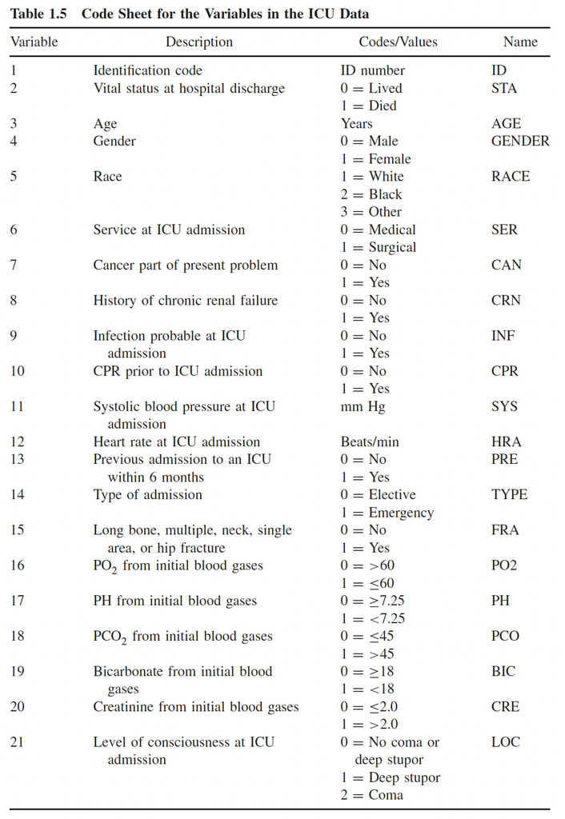

**Important**

The answers in this question are based on “Living” as the reference for STA.

#### Part a

Write down the population equation for the logistic regression model of STA on AGE, CAN, CPR, and INF. How many parameters does this model contain?

**Answer:**

5 parameters

#### Part b

Using `glm()`, obtain the maximum likelihood estimates of the parameters of the logistic regression model in Part a. Using these estimates, write down the equation with the fitted values.

**Answer:**

| term | estimate | std.error | statistic | p.value | conf.low | conf.high |
| --- | --- | --- | --- | --- | --- | --- |
| (Intercept) | −3.621 | 0.790 | −4.582 | 0.000 | −5.321 | −2.202 |
| AGE | 0.028 | 0.011 | 2.466 | 0.014 | 0.007 | 0.052 |
| CANYes | 0.202 | 0.611 | 0.330 | 0.742 | −1.127 | 1.328 |
| CPRYes | 1.637 | 0.616 | 2.659 | 0.008 | 0.425 | 2.881 |
| INFYes | 0.702 | 0.378 | 1.858 | 0.063 | −0.035 | 1.455 |

#### Part c

Assess the significance of the group of coefficients for all variables in the model using the likelihood ratio test. (Hint: part of the ratio in the LRT will be an intercept only model)

```
Likelihood ratio test

Model 1: STA ~ AGE + CAN + CPR + INF
Model 2: STA ~ 1
  #Df   LogLik Df  Chisq Pr(>Chisq)
1   5  -90.204
2   1 -100.080 -4 19.753  0.0005586 ***
---
Signif. codes:  0 '***' 0.001 '**' 0.01 '*' 0.05 '.' 0.1 ' ' 1
```

#### Part d

Fit a new model using only CAN and INF as the predictors, including an interaction between CAN and INF. Is there evidence that our model should have an interaction between CAN and INF (Hint: this requires a formal test of the interaction)?

**Answer:**

| term | estimate | std.error | statistic | p.value | conf.low | conf.high |
| --- | --- | --- | --- | --- | --- | --- |
| (Intercept) | −1.935 | 0.297 | −6.521 | 0.000 | −2.564 | −1.391 |
| CANYes | 0.731 | 0.722 | 1.012 | 0.311 | −0.855 | 2.067 |
| INFYes | 1.081 | 0.387 | 2.792 | 0.005 | 0.336 | 1.864 |
| CANYes:INFYes | −1.669 | 1.323 | −1.262 | 0.207 | −4.868 | 0.759 |

#### Part e

Interpret the odds ratio for the **main effects** in the model from Part d. Please include the 95% confidence interval.

Not given

#### Part f

From the above model, fill out the following table for the odds ratios. Note, you will only need to report two odds ratios and you already have one from Part d & e.

| Cancer | Infection | Estimated odds ratio | 95% CI |
| --- | --- | --- | --- |
| Cancer part of present problem | Infection probable at ICU intake |  |  |
|  | No |  |  |
|  | Yes | FILL HERE | FILL HERE |
| Cancer not part of present problem | Infection probable at ICU intake |  |  |
|  | No |  |  |
|  | Yes | FILL HERE | FILL HERE |

This is a really good way to report odds ratios for interactions between two categorical predictors! Might want to keep this in mind for your project!!

**Answer:**

| Cancer | Infection | Estimated odds ratio | 95% CI |
| --- | --- | --- | --- |
| Cancer part of present problem | Infection probable at ICU intake |  |  |
|  | No |  |  |
|  | Yes | 0.556 | Not given |
| Cancer not part of present problem | Infection probable at ICU intake |  |  |
|  | No |  |  |
|  | Yes | 2.949 | Not given |

#### Part g

Interpret the odds ratio from the table in Part e. Please include the 95% confidence interval. What do you notice about the odds ratios (Hint: Think back to my last slides in Lesson 10: Interactions)?

Not given

#### Part h

Compute the predicted probability for a subject who does not have a present issue with cancer nor an infection upon admittance to the ICU. Compute the 95% confidence interval for the predicted probability. Can you use the Normal approximation?

0.126

#### Part i

Interpret the predicted probability from Part h (right above), including the confidence interval.

Not given

#### Part j

Building off of Part e, fill out the following table for predicted probabilities. What do you notice about the predicted probabilities (Hint: Think back to my last slides in Lesson 10: Interactions)?

| Cancer | Infection | Predicted probability | 95% CI |
| --- | --- | --- | --- |
| Cancer part of present problem | Infection probable at ICU intake |  |  |
|  | No | FILL HERE | FILL HERE |
|  | Yes | FILL HERE | FILL HERE |
| Cancer not part of present problem | Infection probable at ICU intake |  |  |
|  | No | FILL HERE | FILL HERE |
|  | Yes | FILL HERE | FILL HERE |

| Cancer | Infection | Predicted probability | 95% CI |
| --- | --- | --- | --- |
| Cancer part of present problem | Infection probable at ICU intake |  |  |
|  | No |  | 0.002, 0.460 |
|  | Yes | 0.143 |  |
| Cancer not part of present problem | Infection probable at ICU intake |  |  |
|  | No | 0.126 |  |
|  | Yes |  | 0.196, 0.401 |

### Question 2

We will continue with the same dataset from Question 1 above.

#### Part a

Assess the fit of the above model. You may use Hosmer-Lemeshow test or Pearson Residual as appropriate. Discuss your choice and interpret.

Model does not fit data well

#### Part b

Assess the your models ability to discriminate vital status (STA) using AUC.

AUC = 0.6912

#### Part c

Let’s say a colleague found a different preliminary final model than yours. Using the below model that your colleague found, compare your model to theirs using AIC and BIC.

```
Call:  glm(formula = STA ~ SYS + AGE + CPR + INF + AGE * CPR, family = "binomial",
    data = icu2)

Coefficients:
(Intercept)          SYS          AGE       CPRYes       INFYes   AGE:CPRYes
   -1.47960     -0.01343      0.02340     -3.37369      0.53449      0.08370

Degrees of Freedom: 199 Total (i.e. Null);  194 Residual
Null Deviance:      200.2
Residual Deviance: 172.5    AIC: 184.5
```

Not given

## Questions Part 2

The following questions are intended to give you **practice in connecting concepts** that will help you make decisions in real world applications.

### Question 4

Using a similar table to the one in Lesson 8, go back through the parts in this homework and determine which test can be run.

|  | Wald test/CI | Score test | LRT |
| --- | --- | --- | --- |
| Question 1, Part c: testing group of variables |  |  |  |
| Question 1, Part d: testing interaction |  |  |  |
| Question 1, Part e: creating 95% CI for each main effect |  |  |  |
| Question 1, Part f: creating 95% CI for each odds ratio |  |  |  |

One row filled out:

[output not shown]

### Question 5

Look back at our slides for interactions, [particularly the last slide](https://nwakim.github.io/BSTA_513_S25/lessons/10_Interactions/10_Interactions.html#/how-would-i-report-these-results).

#### Part a

In the lecture, we investigated an interaction between a binary variable and a continuous variable. In Question 1 of this homework, we investigated an interaction between two binary variables. What about the variables types were different? How did this change the presentation of estimated odds ratios and predicted probabilities?

#### Part b

How would you present the odds ratios and predicted probabilities if we had an interaction between a 3-category multilevel variable and a continuous variable?

#### Part c

How would you present the odds ratios and predicted probabilities if we had an interaction between a 4-category multilevel variable and a binary variable?